# Norwegian-CDI-WG-production

KM

2024-10-10

As a preparation we first load required libraries and functions:

# Data preparation

There are three key objects needed for all the analyses done and presented here:

1. `responses` matrix (self explanatory)
2. `cdi` data frame (item information)
3. `scores` data frame (participant information: raw scores $ demographics)

We import responses, items, and participant data from local files, which in turn are downloaded from WordBank, exclude non norming (longitudinal?) data, and perform a check (our sums equal to imported scores).

```r
# We get responses and item data:
# wordbankr::get_instrument_data("Norwegian", "WG", item_info=T, administration_info = T) %>% filter(is_norming) -> norwegian_wb_wg
# write_csv(norwegian_wb_wg, file = file.path("Data", "norwegian_wb_wg.csv"))

# More item data available, if needed: modify select():
read_csv("Data/norwegian_wb_wg.csv") %>%
  dplyr::filter(item_kind == "word") %>%
  select(child_id, item_id, item_definition, english_gloss, value) -> responses
```

```r
# We get items (Norwegian, English glosses, and IDs):
responses %>% distinct(item_definition, english_gloss, item_id) -> cdi

# We recode responses into zeroes and ones:
if_else(is.na(responses$value) | responses$value == "understands", 0, 1) -> responses$value

# We get scores and demo data.
# wordbankr::get_administration_data("Norwegian", form = "WG",
#   include_demographic_info = T,
#   include_birth_info = T,
#   include_health_conditions = T,
#   include_language_exposure = T,
#   include_study_internal_id = T) -> norwegian_wb_participants
# write_csv(norwegian_wb_participants, file = file.path("Data", "norwegian_wb_participants.csv"))

# More demo data available, if needed: modify select():
read_csv("Data/norwegian_wb_participants.csv") %>%
  filter(form == "WG" & is_norming) %>%
  select(child_id, age, sex, production) -> scores
# We recode sex (just because we used girl/boy before):
if_else(scores$sex == "Female", "girl",
        if_else(scores$sex == "Male", "boy", scores$sex)) -> scores$sex

# We don't need to filter out longitudinal data, as we used is_norming condition.
# Otherwise some filtering might be needed here.

# We check the sums (should return zero tibble):
responses %>% group_by(child_id) %>% summarise(score = sum(value)) %>%
  full_join(scores) %>% filter(score != production)
```

```
## # A tibble: 0 × 5
## # ℹ 5 variables: child_id <dbl>, score <dbl>, age <dbl>, sex <chr>,
## #   production <dbl>
```

We prepare the responses matrix (eliminating all 0’s and all 1’s items).

Mirt documentation suggests however removing items with difficulties > .95 and < .05. **Check and explore in the future.**

```r
responses %>% group_by(item_id) %>% filter(var(value) > 0) %>%
  pivot_wider(names_from = "item_id", values_from = "value", id_cols = "child_id") -> responses

# We recalculate scores here to maintain the response matrix row order
# (which seems to be messed up with in the process of pivoting above):
responses %>% rowwise() %>% mutate(score = sum(across(starts_with("item_")))) %>%
     select(1, last_col()) %>% left_join(scores) %>% select(- last_col()) -> scores
responses <- as.matrix(select(responses, starts_with("item_")))
cdi %>% filter(item_id %in% colnames(responses)) -> cdi

print(paste0("There are ", nrow(responses), " parents, ", ncol(responses),
             " items (out of ", nrow(cdi), ") with non-zero variance, and ",
             length(which(is.na(responses))), " missing responses."))
```

```
## [1] "There are 2258 parents, 395 items (out of 395) with non-zero variance, and 0 missing responses."
```

# Model creation

For the model creation we start by deciding on the optimal number of quadrature points. With a set number of quadrature points we proceed to fitting the model iteratively, first removing any items without a fit, and then removing all items showing high local dependence and fitting the model again. We continue with removing misfits and locally dependent items if needed.

## Quadrature points

We decide on the number of quadrature points iteratively by fitting models with increasing numbers and comparing their fit. We start with the default and increase it in a number of arbitrary, but hopefully not unreasonable, steps.

We also compare the parameter estimates for the first item, just out of curosity: as the goodness of fit stabilises, so should the estimates.

*It may take some time! Switch eval on only if you really need to recalculate.*

```r
quadpts <- quadpts_comp(responses, quadpts = c(61, 151, 301, 451, 601, 751), NCYCLES = 100000,
             output_file = "Data/norwegian_wg_prod_quadpts.RData")
```

We load the comparison of model fits for different numbers of quadrature points from a file. Here there are:

```r
load("Data/norwegian_wg_prod_quadpts.RData")
quadpts[1:3,]
```

```
##         [,1]      [,2]      [,3]      [,4]      [,5]      [,6]
## quadpts 61        151       301       451       601       751
## conv    TRUE      TRUE      TRUE      TRUE      TRUE      TRUE
## logLik  -109991.2 -109828.7 -109826.7 -109826.7 -109826.7 -109826.7
```

And here are the parameter estimates for the first item:

```r
sapply(1:ncol(quadpts), function(x) quadpts[,x]$item1pars)
```

```
##         [,1]      [,2]      [,3]      [,4]      [,5]      [,6]
## a1  2.171376  2.538064  2.621524  2.621397  2.621457  2.621841
## d  -1.225836 -1.162001 -1.087991 -1.088116 -1.088696 -1.088150
```

```r
quadtp <- 301
```

Based on the above we set the number of quadrature points to 301.

## Model fitting, round 1

We iteratively fit the model and remove any misfits until we have fits for all items.

*It may take some time!*

We save the model to a file to save time in the future (if you want to refit the model, switch the eval on):

```r
model <- misfits_removal(responses=responses, quadtps=quadtp, NCYCLES=100000, p=0.001,
                          output_file = "Data/norwegian_wg_prod.RData")
```

We load the model from a file and print a basic summary:

```r
load("Data/norwegian_wg_prod.RData")
mod <- model[[1]]
items_removed <- model[[2]]
rm(model) # to save space

mod
```

```
##
## Call:
## mirt(data = responses, model = 1, SE = TRUE, quadpts = quadtps,
##     technical = list(NCYCLES = NCYCLES))
##
## Full-information item factor analysis with 1 factor(s).
## Converged within 1e-04 tolerance after 1914 EM iterations.
## mirt version: 1.42
## M-step optimizer: BFGS
## EM acceleration: Ramsay
## Number of rectangular quadrature: 301
## Latent density type: Gaussian
##
## Information matrix estimated with method: Oakes
## Second-order test: model is a possible local maximum
## Condition number of information matrix =  4164.658
##
## Log-likelihood = -109137.5
## Estimated parameters: 784
## AIC = 219842.9
## BIC = 224329.2; SABIC = 221838.3
## G2 (9999999216) = 187610.7, p = 1
## RMSEA = 0, CFI = NaN, TLI = NaN
```

### Items fit

3 items were misfits in the process of model fitting and were removed in 2 iterations before a model with no misfits was obtained.

```r
cdi %>% filter(item_id %in% unlist(items_removed))
```

```
## # A tibble: 3 × 3
##   item_definition english_gloss     item_id
##   <chr>           <chr>             <chr>
## 1 morfar          grandfather       item_262
## 2 oldemor         great grandmother item_265
## 3 blå             blue              item_341
```

```r
if(length(items_removed)) {
  responses <- responses[, -which((colnames(responses) %in% unlist(items_removed)))]
  cdi %>% filter(! item_id %in% unlist(items_removed)) -> cdi
  if (nrow(cdi) == ncol(responses)) print(paste0(ncol(responses), " items left after removal."))
}
```

```
## [1] "392 items left after removal."
```

### Local dependence

*Check and explore the following code in the future (also compare with Kachergis et al., 2022)*

```r
# I can't make the following code hide the results...
residuals <- residuals(mod, df.p=FALSE) # TODO: explore other parameters?
save(residuals, file = "Data/norwegian_wg_prod_residuals.RData")
```

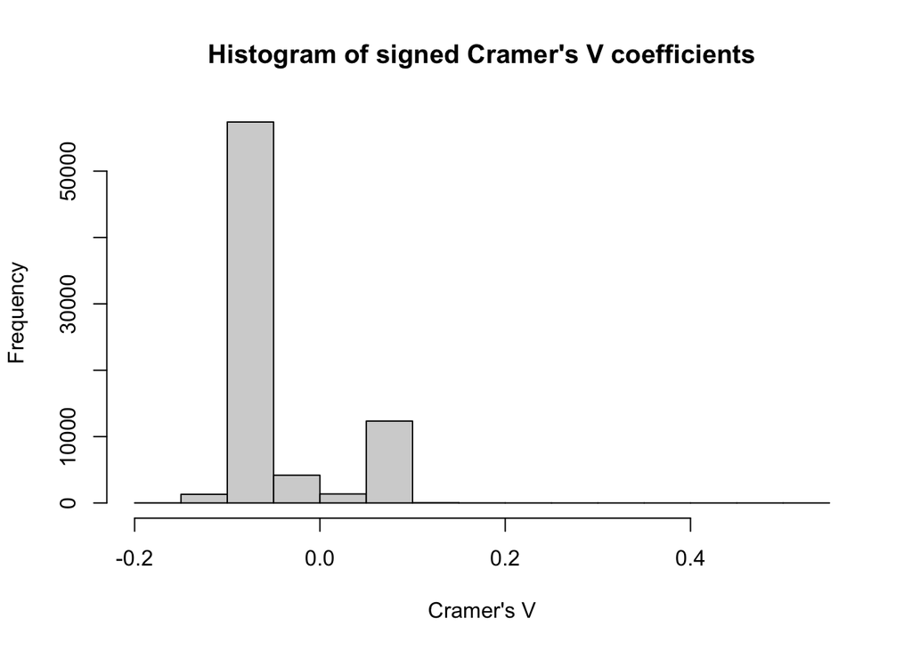

```r
load("Data/norwegian_wg_prod_residuals.RData")
residuals_up <- residuals
residuals_up[lower.tri(residuals_up)] <- NA # upper diagonal contains signed Cramers V coefficients
hist(residuals_up, main="Histogram of signed Cramer's V coefficients", xlab= "Cramer's V")
```

```r
summary(as.vector(residuals_up))[-7]
```

```
##        Min.     1st Qu.      Median        Mean     3rd Qu.        Max.
## -0.17990485 -0.07691781 -0.06857981 -0.04648808 -0.05273426  0.53771920
```

```r
# -7 to avoid reporting NAs, which would be confusing as lower triangle is filled with them
```

To display the most highly mutually dependent items we use V > .3 as the threshold:

```r
indexes <- arrayInd(which(residuals_up > 0.3), dim(residuals))
data.frame(item1 = pull(cdi[indexes[, 1], "english_gloss"]),
           item2 = pull(cdi[indexes[, 2], "english_gloss"]), CramersV = residuals_up[indexes])
```

```
##   item1 item2  CramersV
## 1 mommy daddy 0.5377192
```

```r
indexes <- arrayInd(which(residuals_up > 0.5), dim(residuals))
data.frame(item1 = pull(cdi[indexes[, 1], "item_definition"]),
           item2 = pull(cdi[indexes[, 2], "item_definition"]), CramersV = residuals_up[indexes])
```

```
##   item1 item2  CramersV
## 1 mamma pappa 0.5377192
```

```r
unique(as.vector(indexes)) -> items_to_remove_ids
if(length(items_to_remove_ids)) {
     responses[, -items_to_remove_ids] -> responses
     cdi[-items_to_remove_ids,] -> cdi
}
```

## Model fitting, round 2

Then we repeat the iterative model fit with misfits removal.

```r
model <- misfits_removal(responses=responses, quadtps=quadtp, NCYCLES=100000, p=0.001,
                          output_file = "Data/norwegian_wg_prod_2.RData")
beep()
```

We load the model from a file (comment out if just fitted above) and print a basic summary:

```r
load("Data/norwegian_wg_prod_2.RData")
mod <- model[[1]]
items_removed <- model[[2]]
rm(model) # to save space

mod
```

```
##
## Call:
## mirt(data = responses, model = 1, SE = TRUE, quadpts = quadtps,
##     technical = list(NCYCLES = NCYCLES))
##
## Full-information item factor analysis with 1 factor(s).
## Converged within 1e-04 tolerance after 1887 EM iterations.
## mirt version: 1.42
## M-step optimizer: BFGS
## EM acceleration: Ramsay
## Number of rectangular quadrature: 301
## Latent density type: Gaussian
##
## Information matrix estimated with method: Oakes
## Second-order test: model is a possible local maximum
## Condition number of information matrix =  4192.429
##
## Log-likelihood = -106912.4
## Estimated parameters: 780
## AIC = 215384.8
## BIC = 219848.2; SABIC = 217370
## G2 (9999999220) = 183791.1, p = 1
## RMSEA = 0, CFI = NaN, TLI = NaN
```

### Items fit

0 items were misfits in the process of model fitting and were removed in 0 iterations before a model with no misfits was obtained.

```r
cdi %>% filter(item_id %in% unlist(items_removed))
```

```
## # A tibble: 0 × 3
## # ℹ 3 variables: item_definition <chr>, english_gloss <chr>, item_id <chr>
```

```r
if(length(items_removed)) {
  responses <- responses[, -which((colnames(responses) %in% unlist(items_removed)))]
  cdi %>% filter(! item_id %in% unlist(items_removed)) -> cdi
  if (nrow(cdi) == ncol(responses)) print(paste0(ncol(responses), " items left after removal."))
}
```

### Local dependence

```r
# I can't make the following code hide the results...
residuals <- residuals(mod, df.p=FALSE) # TODO: explore other parameters?
save(residuals, file = "Data/norwegian_wg_prod_residuals_2.RData")
beep()
```

```r
load("Data/norwegian_wg_prod_residuals_2.RData")
residuals_up <- residuals
residuals_up[lower.tri(residuals_up)] <- NA # upper diagonal contains signed Cramers V coefficients
hist(residuals_up, main="Histogram of signed Cramer's V coefficients", xlab= "Cramer's V")
```

```r
summary(as.vector(residuals_up))[-7]
# -7 to avoid reporting NAs, which would be confusing as lower triangle is filled with them
```

```r
indexes <- arrayInd(which(residuals_up > 0.3), dim(residuals))
data.frame(item1 = pull(cdi[indexes[, 1], "english_gloss"]),
           item2 = pull(cdi[indexes[, 2], "english_gloss"]), CramersV = residuals_up[indexes])
```

```r
indexes <- arrayInd(which(residuals_up > 0.5), dim(residuals))
data.frame(item1 = pull(cdi[indexes[, 1], "item_definition"]),
           item2 = pull(cdi[indexes[, 2], "item_definition"]), CramersV = residuals_up[indexes])
unique(as.vector(indexes)) -> items_to_remove_ids
if(length(items_to_remove_ids)) {
     responses[, -items_to_remove_ids] -> responses
     cdi[-items_to_remove_ids,] -> cdi
}
```

# Model exploration

## IRT items parameters

```r
params_IRT <- as.data.frame(coef(mod, simplify = TRUE, IRTpars = TRUE)$items)[1:2]
cdi <- cbind(params_IRT, cdi)
```

Scatterplot of difficulty by discrimination (*we use English glosses; also, if we had categories we could add them as colours*):

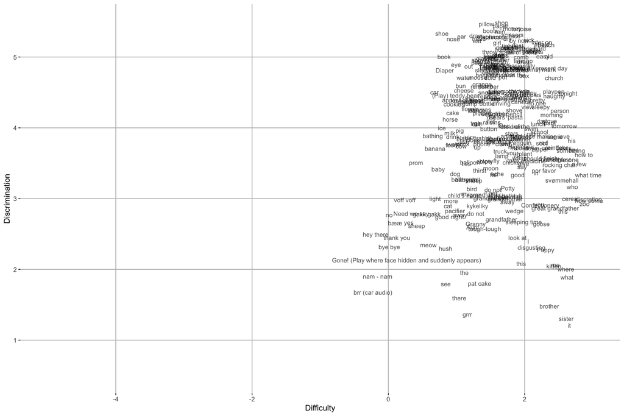

```r
# ggplot(params_cdi, aes(b, a, colour=category, label=position)) +
ggplot(cdi, aes(b, a, label=english_gloss)) +
  geom_text(alpha = 0.7, size=3) +
#  geom_point(alpha = 0.3) +
  xlim(-5, 3) +
  ylim(.5, 5.5) +
  xlab("Difficulty") +
  ylab("Discrimination") +
#  labs(colour = "Category") +
#  labs(title = "Norwegian CDI:WG Production") +
  theme(
  panel.background = element_rect(fill = NA),
  panel.grid.major = element_line(colour = "grey"),
  legend.position = "top"
)
```

## Ability vs. raw scores

We estimate ability levels for children from the sample based on the model.

```r
scores <- cbind(scores, fscores(mod, method = "MAP", full.scores.SE = TRUE))
```

*Explore the failed convergence? Does it have something to do with the chosen MAP method?*

Plot the estimated ability level against raw scores:

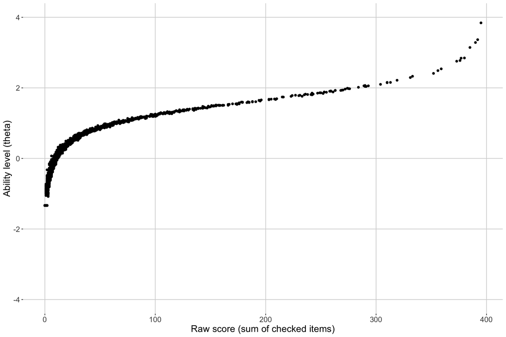

```r
ggplot(scores, aes(score, F1)) +
  geom_point() +
  ylab("Ability level (theta)") +
  xlab("Raw score (sum of checked items)") +
  ylim(-4, 4) +
  theme(
  panel.background = element_rect(fill = NA),
  panel.grid.major = element_line(colour = "lightgrey"),
  text = element_text(size=16)
)
```

```r
# Should be in two separate chunks perhaps?
hist(scores$score, xlab = "Raw sums", main = "")
hist(scores$F1, xlab = "Estimated ability levels", main = "")
```

## Ability vs. SE

Plot the ability level against SE:

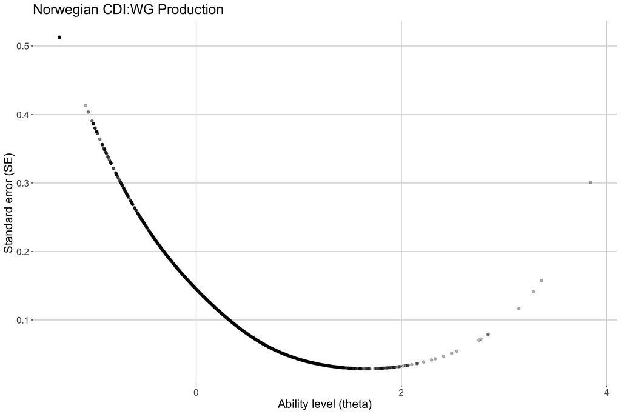

```r
ggplot(scores, aes(F1, SE_F1)) +
  geom_point(alpha = 0.3) +
  xlab("Ability level (theta)") +
  ylab("Standard error (SE)") +
  labs(title = "Norwegian CDI:WG Production") +
  theme(
  panel.background = element_rect(fill = NA),
  panel.grid.major = element_line(colour = "lightgrey"),
  text = element_text(size=16)
)
```

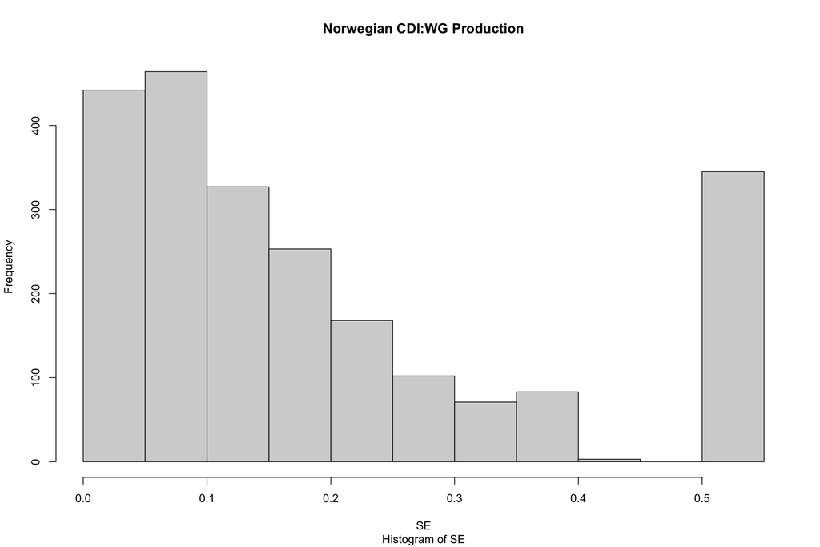

```r
hist(scores$SE_F1, main = "Norwegian CDI:WG Production", sub = "Histogram of SE", xlab = "SE")
```

We can export the data for crosslinguistic plotting/analysing.

```r
write_csv(scores, "Data/scores_Norwegian-WG-prod.csv")
```

## SE and ability level vs. age

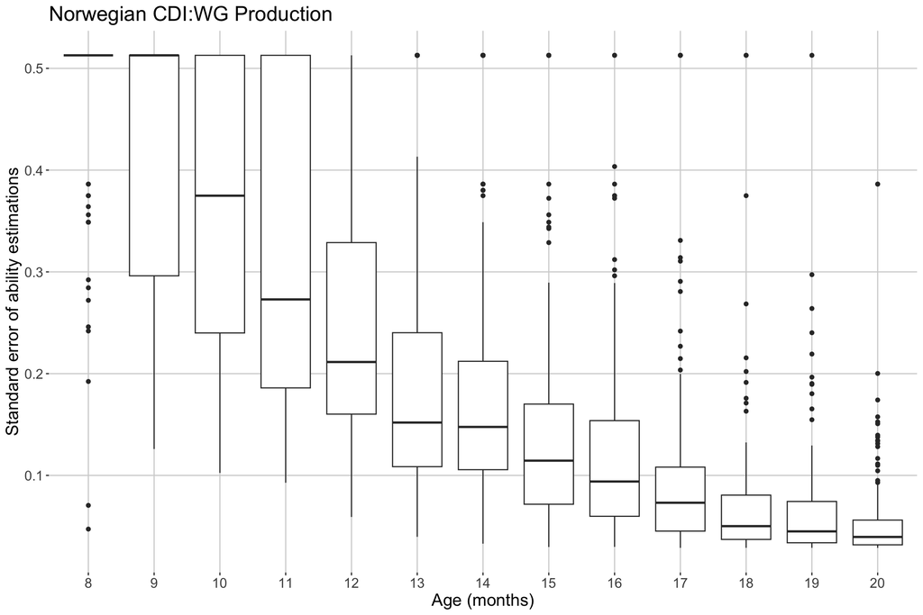

```r
ggplot(data.frame(age = as.factor(scores$age), SE = scores$SE_F1), aes(age, SE)) +
  geom_boxplot() +
  xlab("Age (months)") +
  ylab("Standard error of ability estimations") +
  labs(title = "Norwegian CDI:WG Production") +
  theme(
  panel.background = element_rect(fill = NA),
  panel.grid.major = element_line(colour = "lightgrey"),
  text = element_text(size=16)
  )
```

So let’s see the relation between ability level and age (and first between raw scores and age). We add SE as colour.

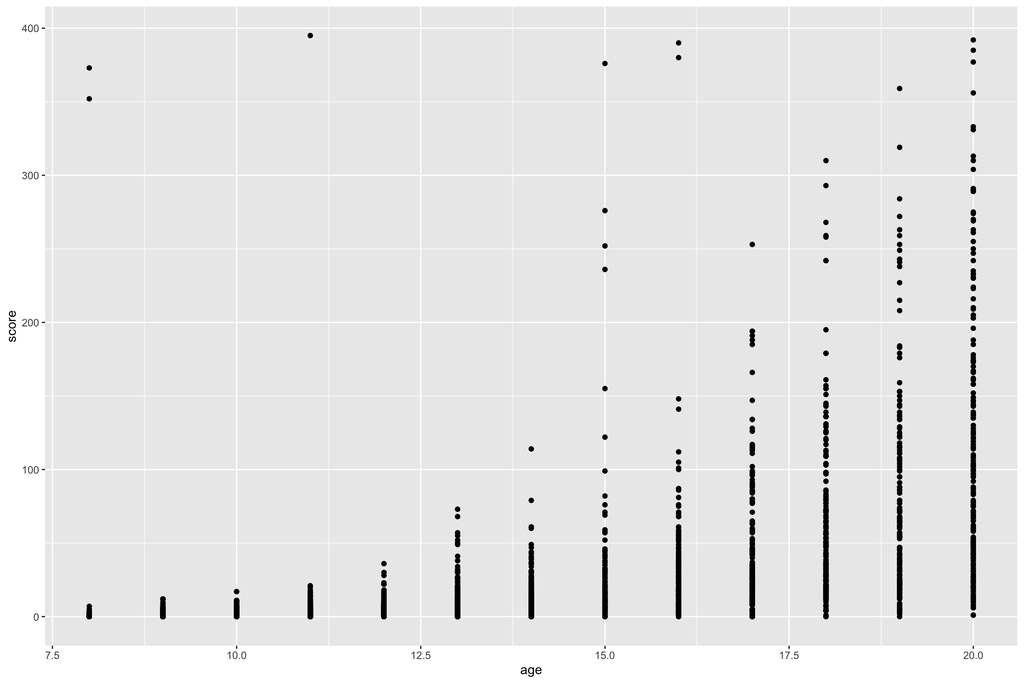

```r
ggplot(scores) +
  geom_point(aes(age, score))
```

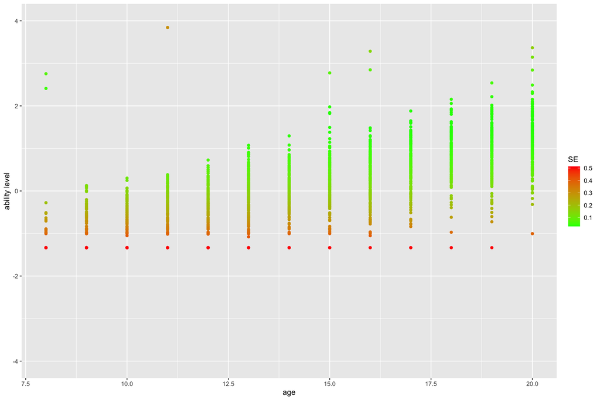

```r
ggplot(scores) +
  geom_point(aes(age, F1, col = SE_F1)) +
  scale_fill_gradient(low="green", high="red", aesthetics = "col") +
  labs(y = "ability level", col = "SE") +
  ylim(-4, 4)
```

# Simulations

```r
params <- as.data.frame(coef(mod, simplify = T)$items)[1:2]
mo <- generate.mirt_object(params, '2PL')
cl <- makeCluster(detectCores())
```

## Whole pool for everyone

```r
message(paste("Starting simulation @ ", Sys.time()))
results_all <- mirtCAT(mo = mo, method = "MAP", criteria = "MI", start_item = "MI",
                       local_pattern = responses, cl = cl, design = list(min_items = ncol(responses)))
# results_all1 <- mirtCAT(mo = mod, method = "MAP", criteria = "MI", start_item = "MI",
#                       local_pattern = responses_r, cl = cl, design = list(min_items = ncol(responses_r)))
save(results_all, file = "Data/norwegian_wg_prod_sim_all.Rdata")
message(paste("Finished @ ", Sys.time()))
beep()
```

```r
load("Data/norwegian_wg_prod_sim_all.Rdata")
report_sim_results(results_all, select(scores, contains("F1")))
```

```
## [1] "Mean length: 390  Median length: 390  Correlation: 1  Mean SE: 0.192  Reliability: 0.963  Unused items: 0"
```

Based on the whole pool simulation we can examine decreasing average SE with each item (we plot it up to 100 items: no need for more).

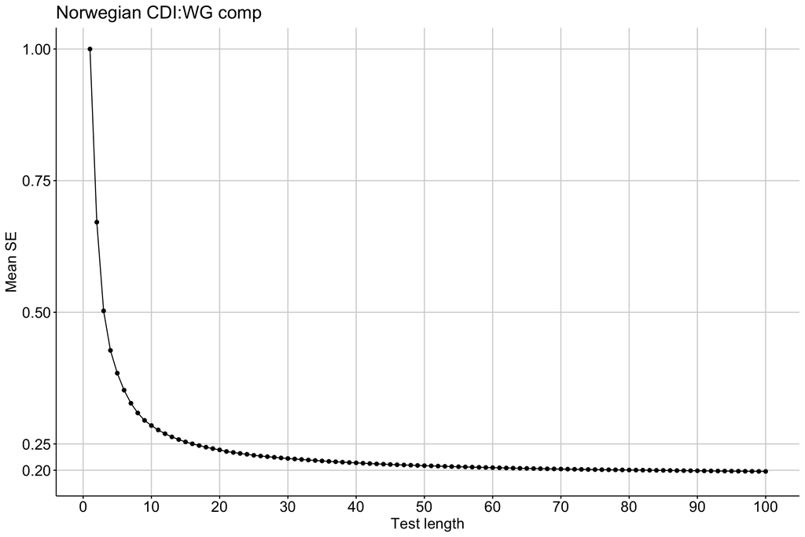

```r
SE_history <- laply(results_all, function(x) x$thetas_SE_history)
meanSE_item <- as.data.frame(colMeans(SE_history))
meanSE_item$item <- row.names(meanSE_item)
colnames(meanSE_item) <- c("mean_SE", "item")
meanSE_item$item <- as.numeric(meanSE_item$item)

ggline(meanSE_item, x = "item", y = "mean_SE", numeric.x.axis = TRUE) +
  xlab ("Test length") +
  ylab ("Mean SE") +
  labs(title = "Norwegian CDI:WG comp") +
  theme(
    panel.background = element_rect(fill = NA),
    panel.grid.major = element_line(colour = "lightgrey"),
    text = element_text(size=16)
  ) +
  scale_y_continuous(breaks = c(0.1, 0.15, 0.2, 0.25, 0.5, 0.75, 1)) +
  scale_x_continuous(breaks = seq(0, nrow(params), by=10), limits = c(1, 100))
```

We can export the data for crosslinguistic plotting/analysing.

```r
write_csv(meanSE_item, "Data/meanSE_Norwegian-WG-prod.csv")
```

## SE = 0.1 stop criterion

```r
results_SE1 <- sim_se(0.1, file = "Data/norwegian_wg_prod_sim_se1.RData")
```

```r
load("Data/norwegian_wg_prod_sim_se1.RData")
results_SE1 <- results
report_sim_results(results_SE1, select(scores, contains("F1")))
```

```
## [1] "Mean length: 248.9  Median length: 390  Correlation: 0.997  Mean SE: 0.209  Reliability: 0.956  Unused items: 0"
```

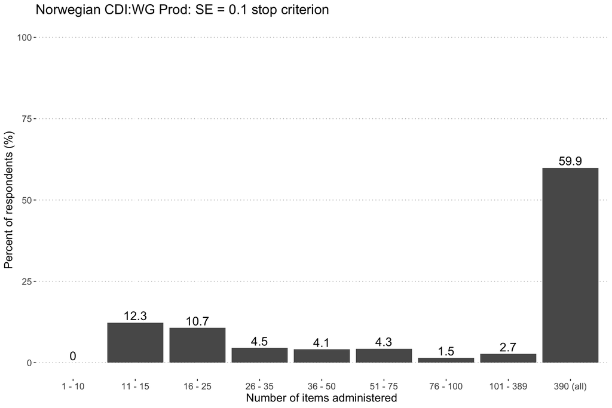

```r
plot_length(results_SE1, "Norwegian CDI:WG Prod", 0.1)
```

## SE = 0.15 stop criterion

```r
 results_SE15 <- sim_se(0.15, file = "Data/norwegian_wg_prod_sim_se15.RData")
beep()
```

```r
load("Data/norwegian_wg_prod_sim_se15.RData")
results_SE15 <- results
report_sim_results(results_SE15, select(scores, contains("F1")))
```

```
## [1] "Mean length: 189.9  Median length: 56  Correlation: 0.993  Mean SE: 0.231  Reliability: 0.947  Unused items: 0"
```

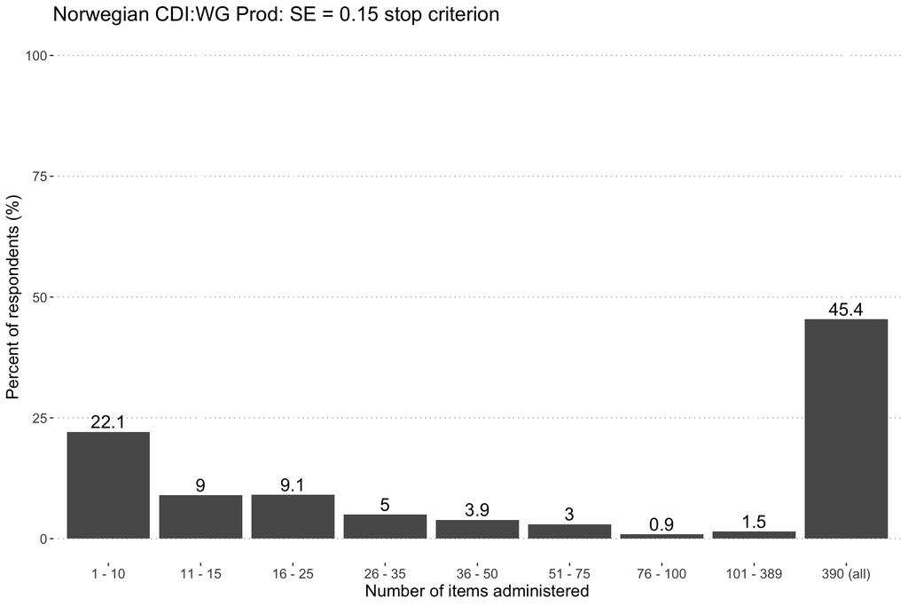

```r
plot_length(results_SE15, "Norwegian CDI:WG Prod", 0.15)
```

## Different start thetas

TODO: Simulations with different start thetas when stop criterion would be specified

# Input files preparation

```r
prepare_input_files(params, cdi$item_definition, fscores_aggr,
                    question = "CATEGORY LABEL here", group = "comp", id = cdi$item_id,
                    file1 = "items-Norwegian-WG-prod.csv", file2 = "startThetas-Norwegian-WG-prod.csv")
```